# Class Preparation

Tim Riffe

June 5, 2019

## You can safely ignore this file

This is a script I just used for warm-up.

## remake final figure from previous session

```r
library(tidyverse)
library(gapminder)
library(ggplot2)
library(socviz)
library(here)
```

This was the object we were using:

```r
by_country <- organdata %>%
    group_by(consent_law, country) %>%
    # nice trick
    summarize_if(is.numeric, list(mean = mean, sd=sd), na.rm = TRUE) %>%
    ungroup()
```

The penultimate plot we made was a dotplot, where countries are ordered by their mean donor rate and colored by consent law. Recall, all those mappings declared inside the `aes()` function!

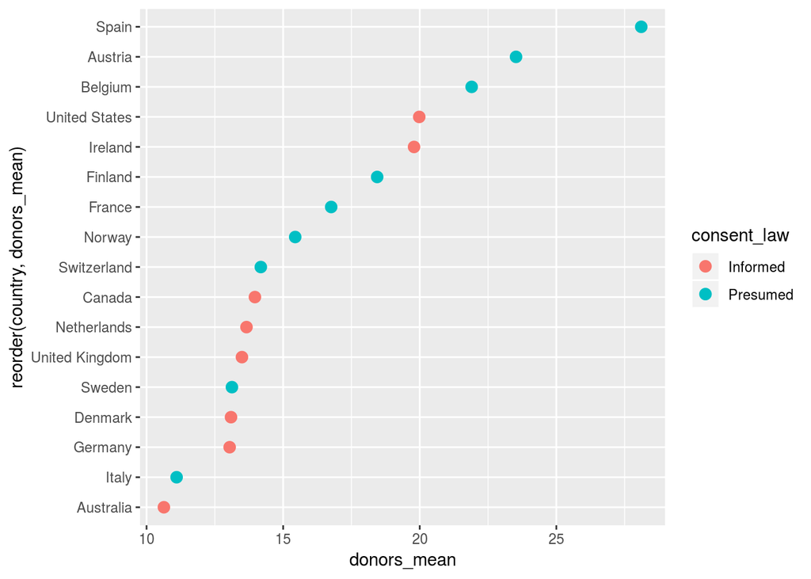

```r
p <- ggplot(data = by_country,
            mapping = aes(
                x = donors_mean,
                y = reorder(country, donors_mean),
                          color = consent_law))
p + geom_point(size = 3)
```

The choice to draw points is declared via the `geom`. Here’s the same plot but showing all datapoints (trends not revealed). TO avoid overlap, we jitter.

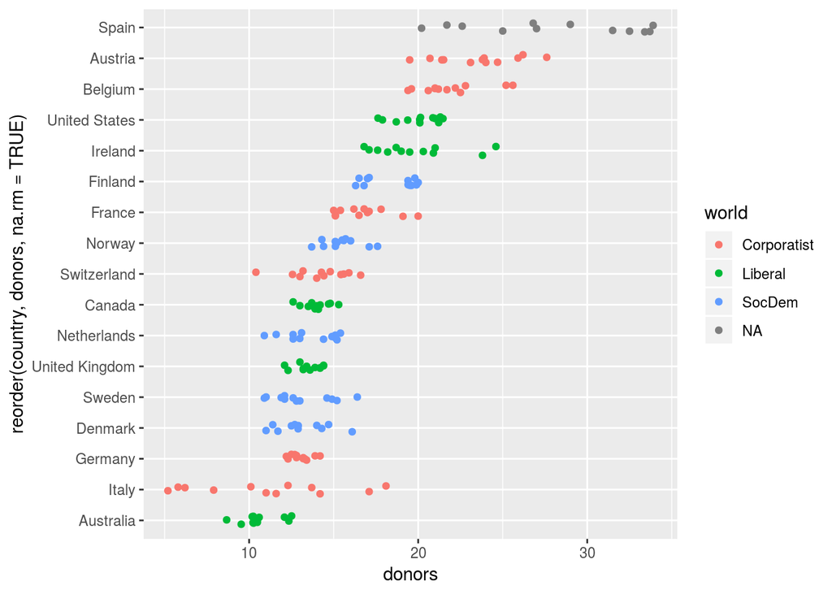

```r
p <- ggplot(data = organdata,
            mapping = aes(x = reorder(country, donors, na.rm =TRUE),
                          y = donors, color = world))
p + geom_jitter(position = position_jitter(width = .15)) + coord_flip()
```

Rather than color, one could use facetting to separate groups, and this might do a better job of revealing differences in patterns between groups.

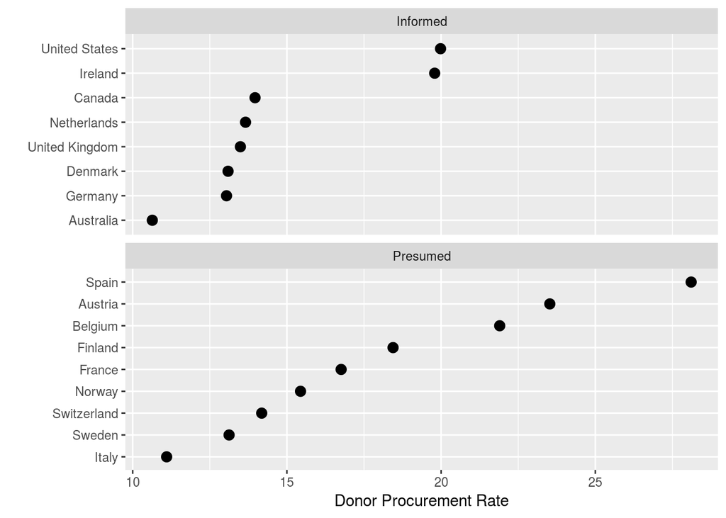

```r
p <- ggplot(data = by_country,
            mapping = aes(x = donors_mean,
                          y = reorder(country, donors_mean)))
p + geom_point(size = 3) +
    facet_wrap(~consent_law, scales = "free_y", ncol = 1) +
    labs(x = "Donor Procurement Rate", y = "")
```

Here we’ve reverted back to points for means, but we can also indicate the range with a line segments, a sort of alternative to the boxplots we drew previously. The `geom` for that is `geom_pointrange`, where we explicit about how to draw the upper and lower bounds to the segments. Here +/- one sd.

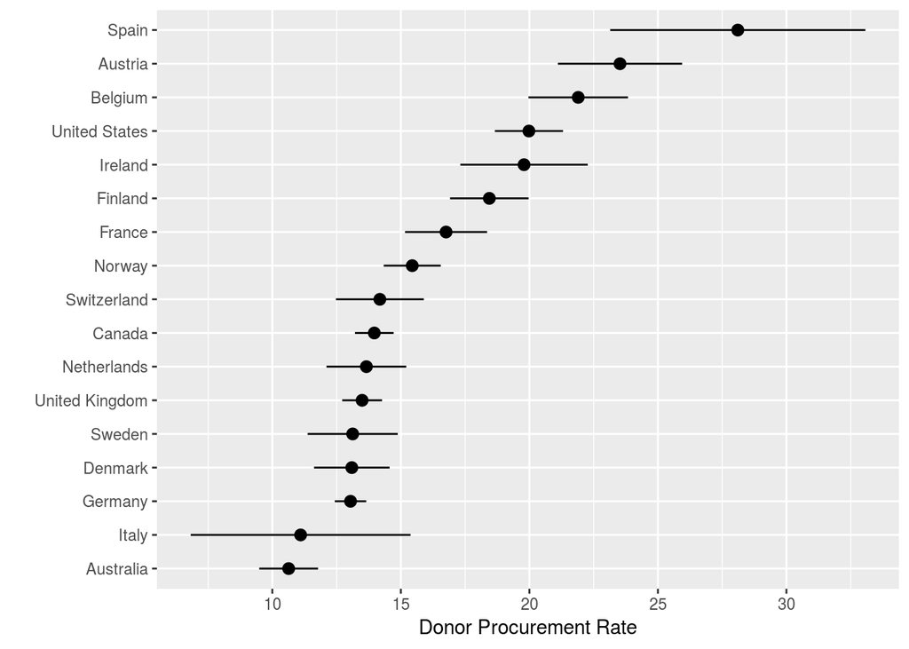

```r
p <- ggplot(data = by_country, mapping = aes(x = reorder(country, donors_mean), y = donors_mean))
p + geom_pointrange(mapping = aes(ymin = donors_mean - donors_sd, ymax = donors_mean + donors_sd)) +
    labs(y = "Donor Procurement Rate", x = "") + coord_flip()
```

How about a labelled scatterplot, in this case showing the relationship between road coverage and donors: better transport (or more accidents?) = more donors? The point here is to use `geom_text()` for adding text to the plot.

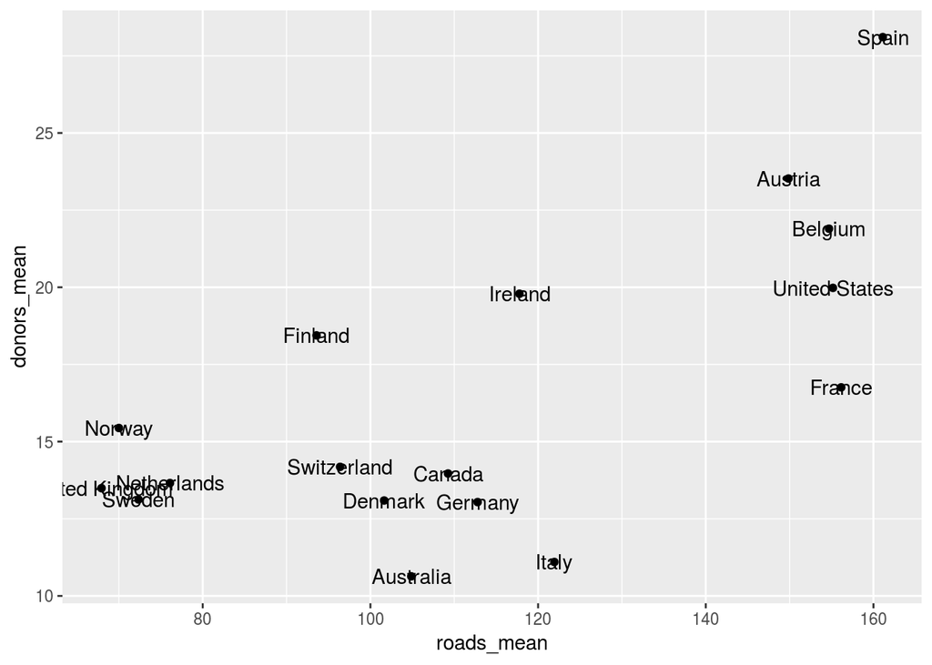

```r
p <- ggplot(data = by_country, mapping = aes(x = roads_mean, y = donors_mean))
p + geom_point() + geom_text(mapping = aes(label = country))
```

uh oh, a bunch of labels are overlapping both with each other and with the data points. We can solve the second one using `hjust = 1` to right justify it:

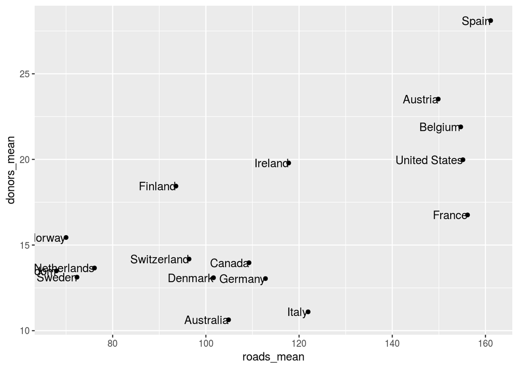

```r
p <- ggplot(data = by_country, mapping = aes(x = roads_mean, y = donors_mean))
p + geom_point() + geom_text(mapping = aes(label = country), hjust = 1)
```

But there’s still overlapping. There’s a package just for solving this problem in `ggplot`: `ggrepel`.

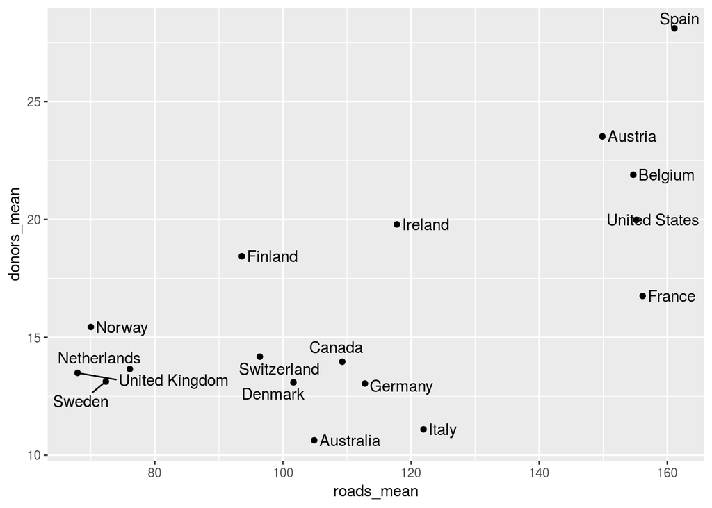

```r
library(ggrepel)
p <- ggplot(data = by_country, mapping = aes(x = roads_mean, y = donors_mean))
p + geom_point() + geom_text_repel(mapping = aes(label = country), hjust = 1)
```

See, it even draws pointers where necessary. Neat trick, saves you an hour or more of fiddling. Optional- recreate the elections graphic from the book. To label just certain points specify the `data` argument inside `geom_text()` or `geom_text_repel()` where the dataset is cut down to just the needed points using `subset()` or similar.

You can add ad hoc text to plots using the `annotate()` geom. Do this liberally!

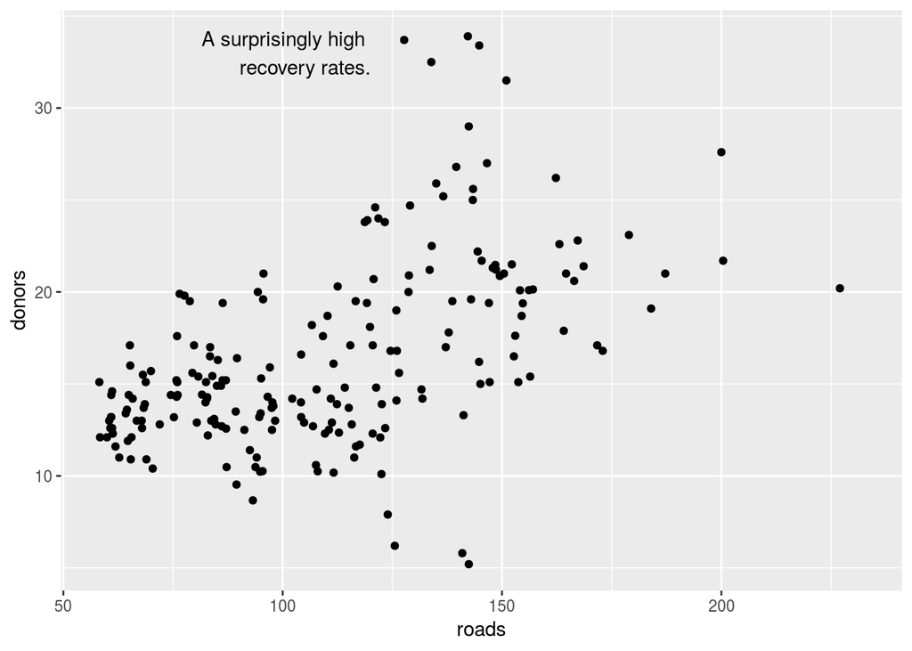

```r
p <- ggplot(data = organdata, mapping = aes(x = roads, y = donors))
p + geom_point() +
    annotate(geom = "text",
             x = 120, y = 33, # explicit location
             label = "A surprisingly high \nrecovery rates.", hjust = 1)
```

Or you might prefer to demarcate a region:

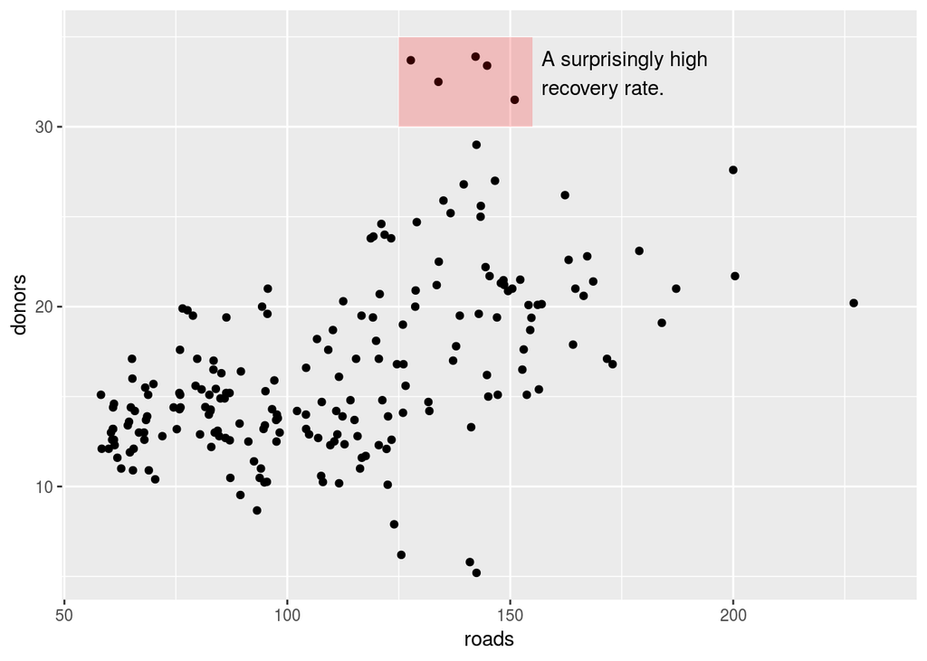

```r
p <- ggplot(data = organdata, mapping = aes(x = roads, y = donors))
p + geom_point() +
    annotate(geom = "rect",
             xmin = 125, xmax = 155,
             ymin = 30, ymax = 35,
             fill = "red", alpha = 0.2) +
    annotate(geom = "text",
             x = 157, y = 33, # explicit location
             label = "A surprisingly high \nrecovery rate.", hjust = 0)
```

Here is an involved example of `ggrepel` and annotation to make a finely curated scatterplot of US presidencies.

```r
elections_historic %>% select(2:7)
```

```
## # A tibble: 49 x 6
##     year winner                 win_party ec_pct popular_pct popular_margin
##    <int> <chr>                  <chr>      <dbl>       <dbl>          <dbl>
##  1  1824 John Quincy Adams      D.-R.      0.322       0.309        -0.104
##  2  1828 Andrew Jackson         Dem.       0.682       0.559         0.122
##  3  1832 Andrew Jackson         Dem.       0.766       0.547         0.178
##  4  1836 Martin Van Buren       Dem.       0.578       0.508         0.142
##  5  1840 William Henry Harrison Whig       0.796       0.529         0.0605
##  6  1844 James Polk             Dem.       0.618       0.495         0.0145
##  7  1848 Zachary Taylor         Whig       0.562       0.473         0.0479
##  8  1852 Franklin Pierce        Dem.       0.858       0.508         0.0695
##  9  1856 James Buchanan         Dem.       0.588       0.453         0.122
## 10  1860 Abraham Lincoln        Rep.       0.594       0.396         0.101
## # … with 39 more rows
```

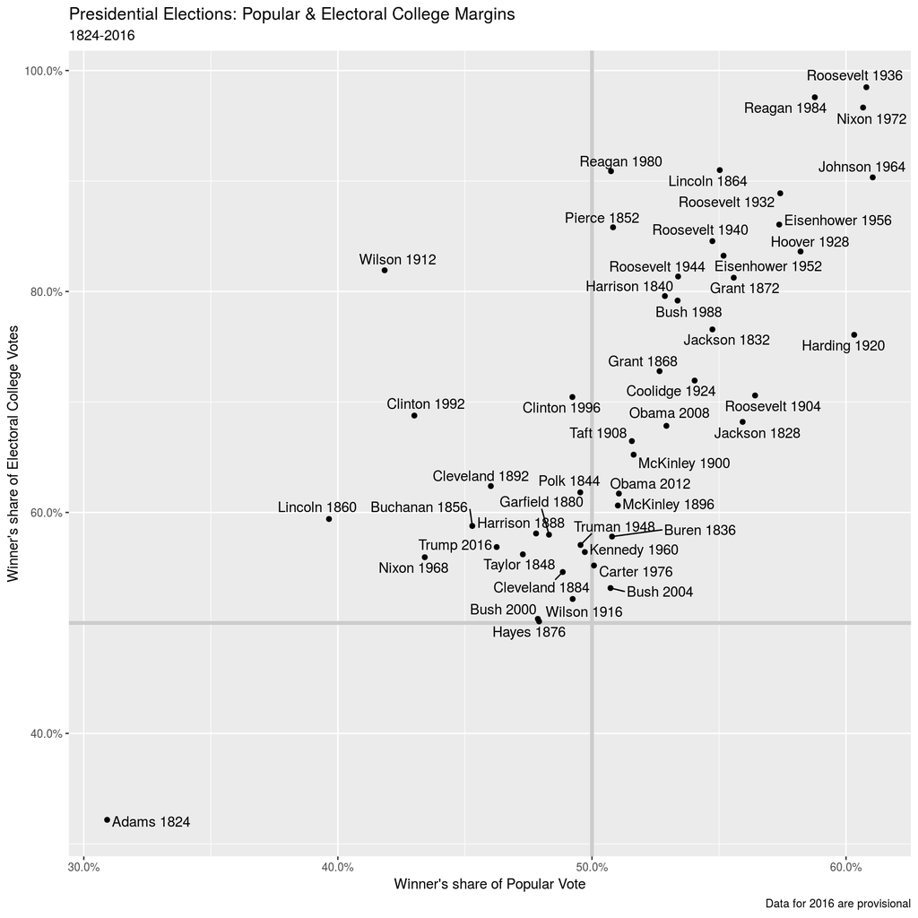

```r
p_title    <- "Presidential Elections: Popular & Electoral College Margins"
p_subtitle <- "1824-2016"
p_caption  <- "Data for 2016 are provisional"
x_label    <- "Winner's share of Popular Vote"
y_label    <- "Winner's share of Electoral College Votes"

p <- ggplot(data = elections_historic,
            mapping = aes(x = popular_pct,
                          y = ec_pct,
                          label = winner_label))
p_out <- p + geom_hline(yintercept = 0.5, size = 1.4, color = gray(.8)) +
    geom_vline(xintercept = 0.5, size = 1.4, color = gray(.8)) +
    geom_point() +
    geom_text_repel() +
    scale_x_continuous(labels = scales::percent) +
    scale_y_continuous(labels = scales::percent) +
    labs(x = x_label,
         y = y_label,
         title = p_title,
         subtitle = p_subtitle,
         caption = p_caption)
p_out
```

```r
# ggsave("Elections.pdf", plot = p_out, height = 10, width = 10)
# getwd()
```

# Chapter 6

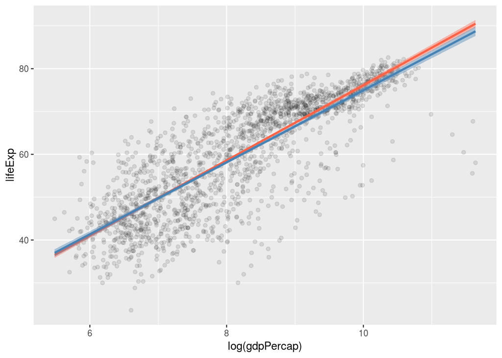

```r
p <- ggplot(data = gapminder,
            mapping = aes(x = log(gdpPercap),
                          y = lifeExp))

p + geom_point(alpha = .1) +
    geom_smooth(color = "tomato", fill = "tomato", method = MASS::rlm)+
    geom_smooth(color = "steelblue", fill = "steelblue", method = lm)
```

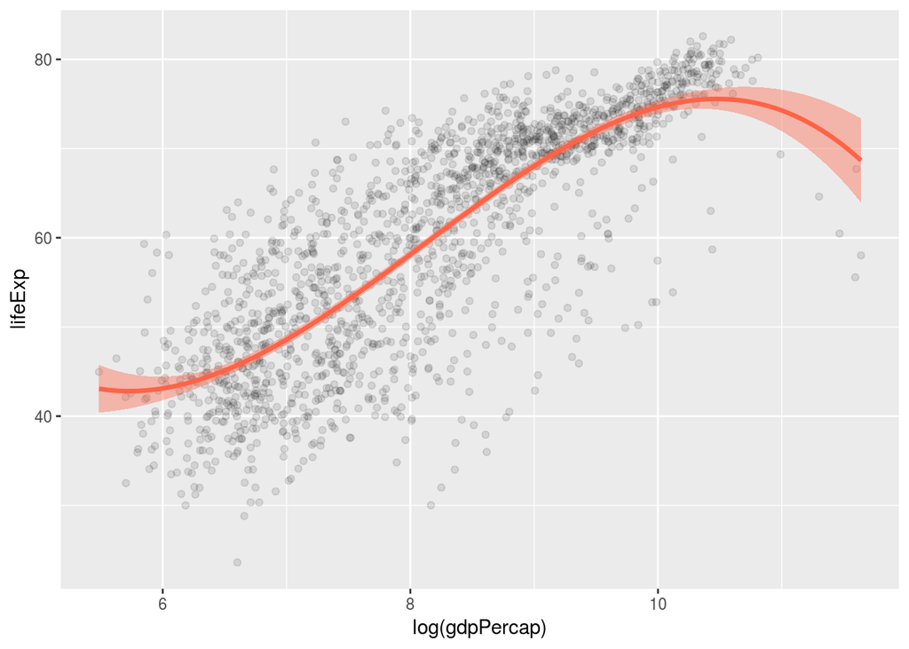

```r
p + geom_point(alpha = .1) +
    geom_smooth(color = "tomato", fill = "tomato", method = "lm", size = 1.2,
                formula = y ~ splines::bs(x,3))
```

```
## Smoothing formula not specified. Using: y ~ qss(x, lambda = 1)
```

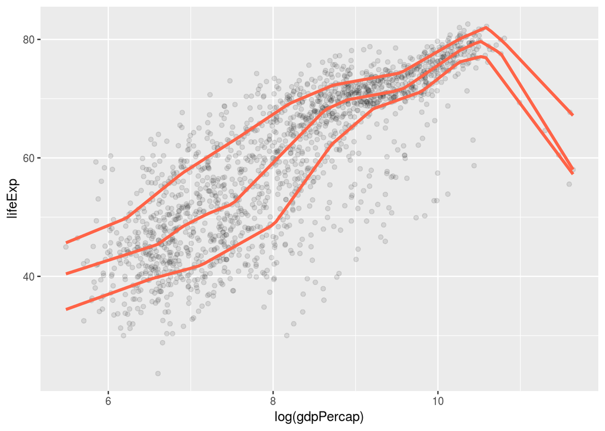

```r
p + geom_point(alpha = .1) +
    geom_quantile(color = "tomato", size = 1.2, method = "rqss",
                  lambda = 1, quantiles = c(.2,.5,.85))
```